# 01.문제풀이

#### 01.기본 데이터 호출 및 라이브러리 호출

##### 기본 데이터 호출 및 라이브러리 호출

```r
load("D:/Project/2020_kakaopay_ds/.RData")

library(sqldf)
library(nortest)
```

##### 데이터 추출 조건 수립

분석환경에 적용하기 쉬운 데이터마트 구조를 재수립하며, 데이터가 모두 RDB환경에 있다는 가정하에  
데이터 추출 (mart)로직을 적용한 SQL로 데이터 구조 수립  
분석 환경의 제약조건으로 인하여 이하 SQL은 모두 SQLite 환경에서 작성

```r
query =
"
select
    claim_user_id,
    sum(total_claim_cnt) as total_cnt,
    sum(send_cnt) as send_cnt,
    count(claim_user_id) as claim_cnt,
    round((sum(send_cnt)+0.00)/(sum(total_claim_cnt)+0.00),4) as recv_rate
from
    (
    select
        claim_user_id ,
        count(claim_id) as total_claim_cnt,
        sum(send_cnt) as send_cnt
    from
        (
        select
            dc.claim_id
            ,dc.claim_user_id
            ,dcd.recv_user_id
            ,dcd.claim_amount
            ,dcd.send_amount
            ,dcd.status
            ,case when dcd.status ='SEND' then 1 else 0 end send_cnt
        from
            dutchpay_claim dc
        join
            dutchpay_claim_detail dcd
            on dc.claim_id =dcd.claim_id
        where
            1=1
            and dc.claim_user_id != dcd.recv_user_id
        )
    group by
        claim_id ,
        claim_user_id
    order by
        claim_user_id
    )
group by
    claim_user_id
"
```

데이터 추출 조건은 각 더치페이 요청id에서 요청id와 응신id를 기준으로 수립되었으며, 요청횟수 대비 응신횟수(send_cnt)를  
집계하여 각 claim_id에서 몇번의 요청과 몇번의 응신이 있었는지를 수치화 작업 진행  
이 때, 요청id와 수신id가 일치(자기 자신에서 더치페이를 요청한 경우)는 제외하는 경우를 두어 데이터 추출 진행 ###

##### 데이터 호출

```r
dataset = sqldf(query)
```

##### 데이터 확인

```r
head(dataset,10)
```

|  | claim_user_id | total_cnt | send_cnt | claim_cnt | recv_rate |
| --- | --- | --- | --- | --- | --- |
| 1 | 0001440cbac4d21 | 2 | 0 | 1 | 0.0000 |
| 2 | 0001f7e9c43abf0 | 6 | 0 | 1 | 0.0000 |
| 3 | 0002af834baa1a8 | 3 | 2 | 1 | 0.6667 |
| 4 | 00043dcb5157e85 | 3 | 1 | 1 | 0.3333 |
| 5 | 0005da54f0216fe | 2 | 1 | 2 | 0.5000 |
| 6 | 000802145306c63 | 8 | 5 | 3 | 0.6250 |
| 7 | 0008f3d9b258023 | 7 | 5 | 3 | 0.7143 |
| 8 | 000aa226f3190a0 | 5 | 2 | 1 | 0.4000 |
| 9 | 000aa70c8a627f7 | 2 | 0 | 1 | 0.0000 |
| 10 | 000caba64e7d179 | 3 | 0 | 3 | 0.0000 |

##### 신규 데이터 필드 정의

total_cnt : 더치페이 요청 유저가 대상자에게 요청한 총 요청횟수  
send_cnt : 더치페이 요청을 받은 유저중 실제로 돈을 보낸 총 횟수  
claim_cnt : 더치페이 요청 건수  
recv_rate : send_cnt / total_cnt (더치페이 응신 비율)

##### 데이터 전체 현황 확인

```r
summary(dataset)
```

```
##          claim_user_id     total_cnt         send_cnt        claim_cnt
##  0001440cbac4d21:    1   Min.   :  1.00   Min.   :  0.00   Min.   :  1.000
##  0001f7e9c43abf0:    1   1st Qu.:  2.00   1st Qu.:  0.00   1st Qu.:  1.000
##  0002af834baa1a8:    1   Median :  4.00   Median :  1.00   Median :  2.000
##  00043dcb5157e85:    1   Mean   :  7.88   Mean   :  2.96   Mean   :  3.003
##  0005da54f0216fe:    1   3rd Qu.:  9.00   3rd Qu.:  3.00   3rd Qu.:  3.000
##  000802145306c63:    1   Max.   :528.00   Max.   :206.00   Max.   :120.000
##  (Other)        :51951
##    recv_rate
##  Min.   :0.0000
##  1st Qu.:0.0000
##  Median :0.2727
##  Mean   :0.3265
##  3rd Qu.:0.5068
##  Max.   :1.0000
##
```

#### 02. 더치페이 응답률과 사용빈도 검토

#### 상관계수 검토

```r
cor.test(dataset$claim_cnt,dataset$recv_rate)
```

```
##
##  Pearson's product-moment correlation
##
## data:  dataset$claim_cnt and dataset$recv_rate
## t = 22.476, df = 51955, p-value < 2.2e-16
## alternative hypothesis: true correlation is not equal to 0
## 95 percent confidence interval:
##  0.08960809 0.10663970
## sample estimates:
##        cor
## 0.09813108
```

더치패이 요청횟수와 응답률은 양의 비례관계를 가지나, 그 값이 크지 않다고 볼 수 있다. 유의미한 수준에서 두 변수간의 관계가 직접적인 영향을 끼친다고 보기 위해선 별도의 조건과 가정을 추가로 진행 해야 한다.

#### 선형회귀모형 검토

```r
summary(lm(dataset$claim_cnt~dataset$recv_rate,data=dataset))
```

```
##
## Call:
## lm(formula = dataset$claim_cnt ~ dataset$recv_rate, data = dataset)
##
## Residuals:
##     Min      1Q  Median      3Q     Max
##  -2.837  -1.598  -1.598   0.247 116.465
##
## Coefficients:
##                   Estimate Std. Error t value Pr(>|t|)
## (Intercept)        2.59815    0.02557  101.60   <2e-16 ***
## dataset$recv_rate  1.23850    0.05510   22.48   <2e-16 ***
## ---
## Signif. codes:  0 '***' 0.001 '**' 0.01 '*' 0.05 '.' 0.1 ' ' 1
##
## Residual standard error: 4.142 on 51955 degrees of freedom
## Multiple R-squared:  0.00963,    Adjusted R-squared:  0.009611
## F-statistic: 505.2 on 1 and 51955 DF,  p-value: < 2.2e-16
```

y(claim_cnt) ~ x(recv_rate)에 대한 선형회귀 검토 결과 결정계수가 0.01에 수렴하는것으로 확인 되었으며, 두 값에 대한 선형적 회귀모형 관계는 유추하기 어렵다고 해석 할 수 있다.

#### 03. 더치페이 응답률에 따른 더치페이 서비스 이용수준 가설 수립

##### 더치페이 사용 비율에 대한 누적밀도 그래프 검토

전체 데이터기준에서 안분하기 위한 기준로 우선 더치페이 요청횟수(claim_cnt)를 중위값(median)을 기준점으로 요청횟수가 많은 집단, 적은 집단으로 각각 안분하여 수행  
우선 claim_cnt(더치페이 요청건수)가 클수록 recv_rate(더치페이 응답률)과 관계가 있는지를 누적밀도 그래프로 측정

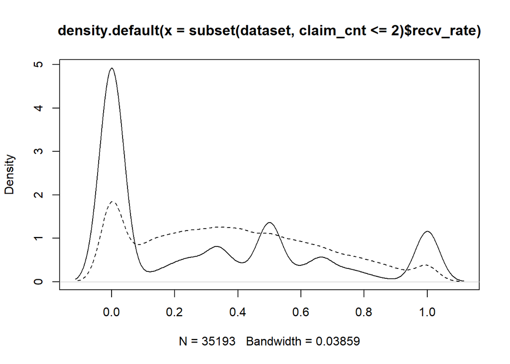

```r
plot(density(subset(dataset,claim_cnt<=2)$recv_rate))
lines(density(subset(dataset,claim_cnt>2)$recv_rate),lty=2)
```

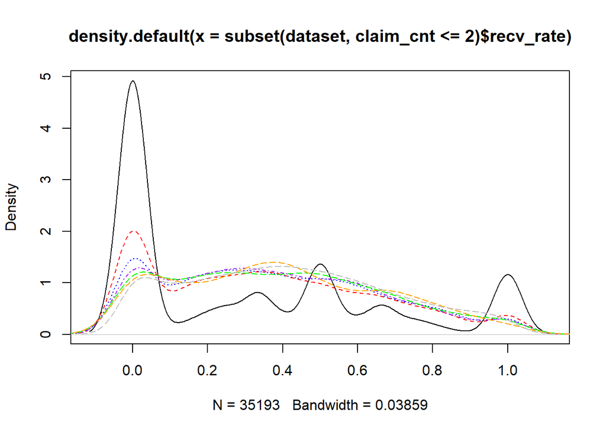

```r
plot(density(subset(dataset,claim_cnt<=2)$recv_rate))
lines(density(subset(dataset,claim_cnt==3)$recv_rate),lty=2,col='red')
lines(density(subset(dataset,claim_cnt==4)$recv_rate),lty=3,col='blue')
lines(density(subset(dataset,claim_cnt==5)$recv_rate),lty=4,col='purple')
lines(density(subset(dataset,claim_cnt==6)$recv_rate),lty=5,col='green')
lines(density(subset(dataset,claim_cnt==7)$recv_rate),lty=5,col='orange')
lines(density(subset(dataset,claim_cnt>=8)$recv_rate),lty=5,col='gray')
```

각 데이터 집단에 대한 세부적인 검토를 위해 각각 claim_cnt 2,3,4,5,6,7,8이상의 개별적인 집단에서 recv_rate를 모두 누적밀도분포를 검토한 결과  
claim_cnt가 커질 수록 recv_rate가 보다 완만한 형태의 누적분포를 이루고 있음을 확인할 수 있으며  
이는 recv_rate와 claim_cnt간에 유의미한 관계가 있음을 유추할 수 있는 근거로 파악할 수 있다.

다음으로 더치페이 응답률(recv_rate)의 중위값(median)을 기준점으로 요청횟수가 많은 집단, 적은 집단으로 각각 안분하여 수행  
recv_rate(더치페이 응답률)가 클수록 claim_cnt(더치페이 요청건수) 와 관계가 있는지를 누적밀도 그래프로 측정

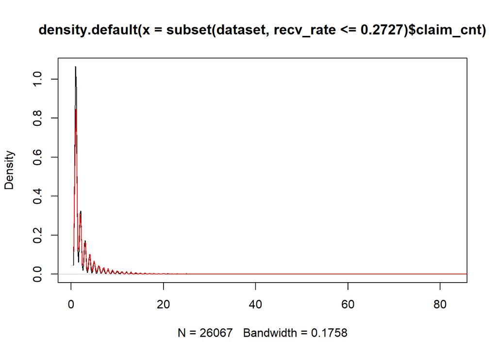

```r
plot(density(subset(dataset,recv_rate<=0.2727)$claim_cnt))
lines(density(subset(dataset,claim_cnt>0.2727)$claim_cnt),col="red")
```

#### 04. 가설 수립 및 검토

##### t검정을 위한 기준 수립 :claim_cnt 기준 측정

설정된 두 집단은 다음과 같이 정의 할 수 있다

집단 1 : 더치페이 요청횟수 2회 이하에서 확인 가능한 더치페이 응답률  
집단 2 : 더치페이 요청횟수 3회 이상에서 확인 가능한 더치페이 응답률

가설 수립  
귀무가설 : 집단1(더치페이 요청회수 2회 이하) 인 집단과 집단2(더치페이 요청횟수 3회 이상)인 집단의 더치페이 응답률의 평균 차이가 없다  
대립가설 : 집단1과 집단2의 더치페이 응답률의 평균에 차이가 있다.

집단1에 대한 데이터 분포 확인

```r
summary(subset(dataset,claim_cnt<=2))
```

```
##          claim_user_id     total_cnt         send_cnt        claim_cnt
##  0001440cbac4d21:    1   Min.   : 1.000   Min.   : 0.000   Min.   :1.000
##  0001f7e9c43abf0:    1   1st Qu.: 2.000   1st Qu.: 0.000   1st Qu.:1.000
##  0002af834baa1a8:    1   Median : 3.000   Median : 1.000   Median :1.000
##  00043dcb5157e85:    1   Mean   : 3.337   Mean   : 1.098   Mean   :1.265
##  0005da54f0216fe:    1   3rd Qu.: 4.000   3rd Qu.: 2.000   3rd Qu.:2.000
##  000aa226f3190a0:    1   Max.   :70.000   Max.   :35.000   Max.   :2.000
##  (Other)        :35187
##    recv_rate
##  Min.   :0.0000
##  1st Qu.:0.0000
##  Median :0.1935
##  Mean   :0.3007
##  3rd Qu.:0.5000
##  Max.   :1.0000
##
```

```r
summary(subset(dataset,claim_cnt>3))
```

```
##          claim_user_id     total_cnt        send_cnt         claim_cnt
##  002b3da95adc9e5:    1   Min.   :  4.0   Min.   :  0.000   Min.   :  4.000
##  002c0b0fddf15a3:    1   1st Qu.: 10.0   1st Qu.:  2.000   1st Qu.:  4.000
##  002e2194810bb6c:    1   Median : 15.0   Median :  6.000   Median :  6.000
##  0031e670b65ed99:    1   Mean   : 21.4   Mean   :  8.529   Mean   :  8.197
##  003b1345069c3a3:    1   3rd Qu.: 25.0   3rd Qu.: 11.000   3rd Qu.:  9.000
##  003d24649c4fb7a:    1   Max.   :528.0   Max.   :206.000   Max.   :120.000
##  (Other)        :11768
##    recv_rate
##  Min.   :0.0000
##  1st Qu.:0.1667
##  Median :0.3750
##  Mean   :0.3920
##  3rd Qu.:0.5882
##  Max.   :1.0000
##
```

t검정 진행

```r
t.test(
    subset(dataset,claim_cnt <=2)$recv_rate,
    subset(dataset,claim_cnt > 2)$recv_rate,
    # alternative = "greater",
    var.equal = FALSE
)
```

```
##
##  Welch Two Sample t-test
##
## data:  subset(dataset, claim_cnt <= 2)$recv_rate and subset(dataset, claim_cnt > 2)$recv_rate
## t = -28.071, df = 40114, p-value < 2.2e-16
## alternative hypothesis: true difference in means is not equal to 0
## 95 percent confidence interval:
##  -0.08560323 -0.07442909
## sample estimates:
## mean of x mean of y
## 0.3006994 0.3807155
```

(t검정에서 데이터의 등분산성의 경우, 두 데이터 집단이 등분산성을 가지지 않으므로 t.test에서 이분산 검정으로 진행된다)

t검정 결과, p-value가 귀무가설을 기각 하므로, 두 집단의 차이는 유의미 하다고 볼 수 있으며, 이는 최초 문제 설정 기준에서 제시되었던  
더치페이 응답률이 높을 수록 더치페이 요청횟수가 많아진다는 질문에 대한 귀납적 접근으로 해석 할 수 있다.

아울러 요청횟수 2이하의 집단의 경우 더치페이 응답률 평균 0.3006994 인데 반하여  
더치페이 요청횟수 3이상인 집단에서의 더치페이 응답률 평균 0.3807155으로 상대적으로 더 높은 수준의 응답률을 고려 했을 때,  
더치페이 응답률이 높을 경우 상대적으로 더 많은 더치페이 요청횟수를 나타낸다고 할 수 있다.

##### t검정을 위한 기준 수립 :recv_rate 기준

설정된 두 집단은 다음과 같이 정의 할 수 있다

집단 1 : 더치페이 응답률이 27.27% 이하에서 확인 가능한 더치페이 요청건수  
집단 2 : 더치페이 응답률이 27.27% 를 초과하는 확인 가능한 더치페이 요청건수

가설 수립  
귀무가설 : 집단1(더치페이 응답률 <=27.27%) 인 집단과 집단2(더치페이 응답률> 27.27%)인 집단의 더치페이 응답률의 평균 차이가 없다  
대립가설 : 집단1과 집단2의 더치페이 요청건수의 평균에 차이가 있다.

집단1에 대한 데이터 분포 확인

```r
summary(subset(dataset,recv_rate<=0.2727))
```

```
##          claim_user_id     total_cnt          send_cnt         claim_cnt
##  0001440cbac4d21:    1   Min.   :  1.000   Min.   : 0.0000   Min.   : 1.000
##  0001f7e9c43abf0:    1   1st Qu.:  1.000   1st Qu.: 0.0000   1st Qu.: 1.000
##  000aa70c8a627f7:    1   Median :  3.000   Median : 0.0000   Median : 1.000
##  000caba64e7d179:    1   Mean   :  6.237   Mean   : 0.5836   Mean   : 2.506
##  000d790f8c71f9c:    1   3rd Qu.:  7.000   3rd Qu.: 1.0000   3rd Qu.: 3.000
##  0013b794cac2c15:    1   Max.   :528.000   Max.   :51.0000   Max.   :82.000
##  (Other)        :26061
##    recv_rate
##  Min.   :0.00000
##  1st Qu.:0.00000
##  Median :0.00000
##  Mean   :0.04684
##  3rd Qu.:0.05260
##  Max.   :0.27270
##
```

집단2에 대한 데이터 분포 확인

```r
summary(subset(dataset,recv_rate>0.2727))
```

```
##          claim_user_id     total_cnt          send_cnt         claim_cnt
##  0002af834baa1a8:    1   Min.   :  1.000   Min.   :  1.000   Min.   :  1.000
##  00043dcb5157e85:    1   1st Qu.:  3.000   1st Qu.:  2.000   1st Qu.:  1.000
##  0005da54f0216fe:    1   Median :  5.000   Median :  3.000   Median :  2.000
##  000802145306c63:    1   Mean   :  9.534   Mean   :  5.353   Mean   :  3.502
##  0008f3d9b258023:    1   3rd Qu.: 11.000   3rd Qu.:  6.000   3rd Qu.:  4.000
##  000aa226f3190a0:    1   Max.   :260.000   Max.   :206.000   Max.   :120.000
##  (Other)        :25884
##    recv_rate
##  Min.   :0.2745
##  1st Qu.:0.4286
##  Median :0.5172
##  Mean   :0.6081
##  3rd Qu.:0.7500
##  Max.   :1.0000
##
```

t검정 진행

```r
t.test(
    subset(dataset,recv_rate <=0.2727 )$claim_cnt,
    subset(dataset,recv_rate > 0.2727 )$claim_cnt,
    # alternative = "greater",
    var.equal = FALSE
)
```

```
##
##  Welch Two Sample t-test
##
## data:  subset(dataset, recv_rate <= 0.2727)$claim_cnt and subset(dataset, recv_rate > 0.2727)$claim_cnt
## t = -27.432, df = 48421, p-value < 2.2e-16
## alternative hypothesis: true difference in means is not equal to 0
## 95 percent confidence interval:
##  -1.0665933 -0.9243415
## sample estimates:
## mean of x mean of y
##  2.506502  3.501970
```

(t검정에서 데이터의 등분산성의 경우, 두 데이터 집단이 등분산성을 가지지 않으므로 t.test에서 이분산 검정으로 진행된다)

t검정 결과, p-value가 귀무가설을 기각 하므로, 두 집단의 차이는 유의미 하다고 볼 수 있으며, 이는 최초 문제 설정 기준에서 제시되었던  
더치페이 응답률이 높을 수록 더치페이 요청횟수가 많아진다는 질문에 대한 귀납적 접근으로 해석 할 수 있다.

아울러 더치페이 응답률 27.27% 이하의 집단의 경우 평균 더치페이 요청이 2.5회인 것에 반하여 아울러 더치페이 응답률 27.27%를 초과하는 집단의 경우 평균 더치페이 요청이 3.5회로 나타나는 것을 확인 할 수 있다.  
따라서 더치페이 응답률이 높을 수록 더치페이 요청 횟수가 많다는 것을 확인 할 수 있다.

#### 05. 결론

##### claim_cnt를 기준으로 recv_rate가 각 두집단에서 유의미한 차이가 있음을 확인 할 수 있으며

##### 마찬가지로 recv_reate를 기준으로 각 두집단에서 유의미한 차이가 있음을 확인 할 수 있다.

##### 따라서 문제에서 제시된 응답률이 높을 수록 더치페이 요청이 더 많을 것이다라는 가정에는 충분히

##### 부합할 수 있는 기준과 근거를 확인 했다고 할 수 있다.

아울러 recv_rate <=0.2727에서 평균 claim_cnt는 2.5회, recv_rate>0.2727에서 평균 claim_cnt는 3.5회로 확인된다.

결론 : 더치페이 응답률이 높으면 더치페이 서비스를 더 쓰는 것으로 확인 할 수 있다.